# Predicting exercise execution with accelerometers data

Paul Degtyariov

12 05 2020

# Preparing the data

## Activating packages

```r
library(dplyr)
library(tidyr)
library(stringr)
library(ggplot2)
library(psych)
library(knitr)

# Here I will use xgboost and ranger packages as they provide convient and fast implementations of classification trees
library(xgboost)
library(ranger)
```

## Loading the data

```r
url_train <- "https://d396qusza40orc.cloudfront.net/predmachlearn/pml-training.csv"
url_test <- "https://d396qusza40orc.cloudfront.net/predmachlearn/pml-testing.csv"
path <- getwd()

if(length(grep("pml-trainin.csv",list.files()))==0) {download.file(url,file.path(path,"pml-trainin.csv"))} else print("Downloaded")


if(length(grep("pml-testing.csv",list.files()))==0) {download.file(url,file.path(path,"pml-testing.csv"))} else print("Downloaded")

train_data <- read.csv(paste0(path,"/pml-trainin.csv"),stringsAsFactors=FALSE)
test_data <- read.csv(paste0(path,"/pml-testing.csv"),stringsAsFactors=FALSE)
```

## Processing the data

We would want to remove characters from the data column that should be numeric, impute the NAs with by person mean and eliminate any columns that are empty in training set. Additionally we will remove identifications variables besides username, and perform z-score transformation on the rest of variables.

```r
train_data1 <- train_data %>%
    mutate_all(funs(str_remove_all(.,"#DIV/0!"))) %>%
    mutate_at(vars(c(8:ncol(train_data)-1)),as.numeric) %>%
    group_by(user_name) %>%
    mutate_at(vars(8:ncol(train_data)-1),funs(ifelse(is.na(.),mean(.,na.rm=T),.))) %>%
    mutate_at(vars(8:ncol(train_data)-1),funs(ifelse(is.nan(.),mean(.,na.rm=T),.))) %>%
    ungroup() %>%
    mutate(user_name=paste(X,user_name,sep="_")) %>%
    select(user_name,classe,9:ncol(train_data)-1)

#Removing columns with NA/NaN only
train_data1 <- train_data1[colSums(!is.na(train_data1)) > 0]
train_data1 <- train_data1[,!sapply(train_data1, function(x) sum(is.nan(x)>0))]

#Removing columns with zero variance
check_sd <- function(x){
    if(is.numeric(x)) sd(x,na.rm=T)!=0
    else TRUE
}
train_data1 <- train_data1[,sapply(train_data1,check_sd)]

#We will need mean and sd parameters for every value besides user_name and classe to perform the same z-score transformation on test set
z_mean <- apply(train_data1[,-c(1,2)],2,mean)
z_sd <- apply(train_data1[,-c(1,2)],2,sd)

for(i in 1:133){
  train_data1[,i+2] <- (train_data1[,i+2]-z_mean[i])/z_sd[i]
}

#Now the same with the test set

test_data1 <- test_data %>%
    mutate_all(funs(str_remove_all(.,"#DIV/0!"))) %>%
    mutate_at(vars(8:ncol(test_data)-1),as.numeric) %>%
    group_by(user_name) %>%
    mutate_at(vars(8:ncol(test_data)-1),funs(ifelse(is.na(.),mean(.,na.rm=T),.))) %>%
    ungroup() %>%
    mutate(user_name=paste(X,user_name,sep="_")) %>%
    select(user_name,classe,9:ncol(test_data)-1)

test_data1 <- test_data1[,which(names(test_data1) %in% names(train_data1))]

for(i in 1:133){
  test_data1[,i+2] <- (test_data1[,i+2]-z_mean[i])/z_sd[i]
}
```

## Reducing number of predictors

As there are lot’s of possible predcitors in the data, we can try PCA to reduce their numbers while removing co-liner predictors and hopeful reducing random error

```r
cor_m <- cor(train_data1[sapply(train_data1,is.numeric)],use="pairwise.complete.obs")

fa.parallel(x=cor_m,n.obs=19622,fm="minres",fa="pc")
```

```
## In factor.scores, the correlation matrix is singular, an approximation is used
```

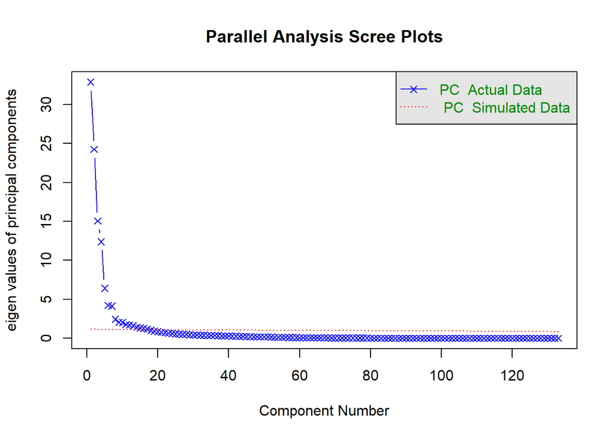

```
## Parallel analysis suggests that the number of factors =  NA  and the number of components =  17
```

```r
# Parallel analysis with simulation comparison is suggests 17 principal components are reasonable
PCA <- pca(r=cor_m,nfactors=17,rotate="none",n.obs=19622)

summary(PCA)
```

```
##
## Factor analysis with Call: principal(r = r, nfactors = nfactors, residuals = residuals,
##     rotate = rotate, n.obs = n.obs, covar = covar, scores = scores,
##     missing = missing, impute = impute, oblique.scores = oblique.scores,
##     method = method, use = use, cor = cor, correct = 0.5, weight = NULL)
##
## Test of the hypothesis that 17 factors are sufficient.
## The degrees of freedom for the model is 6653  and the objective function was  296.4
## The number of observations was  19622  with Chi Square =  5798995  with prob <  0
##
## The root mean square of the residuals (RMSA) is  0.01
```

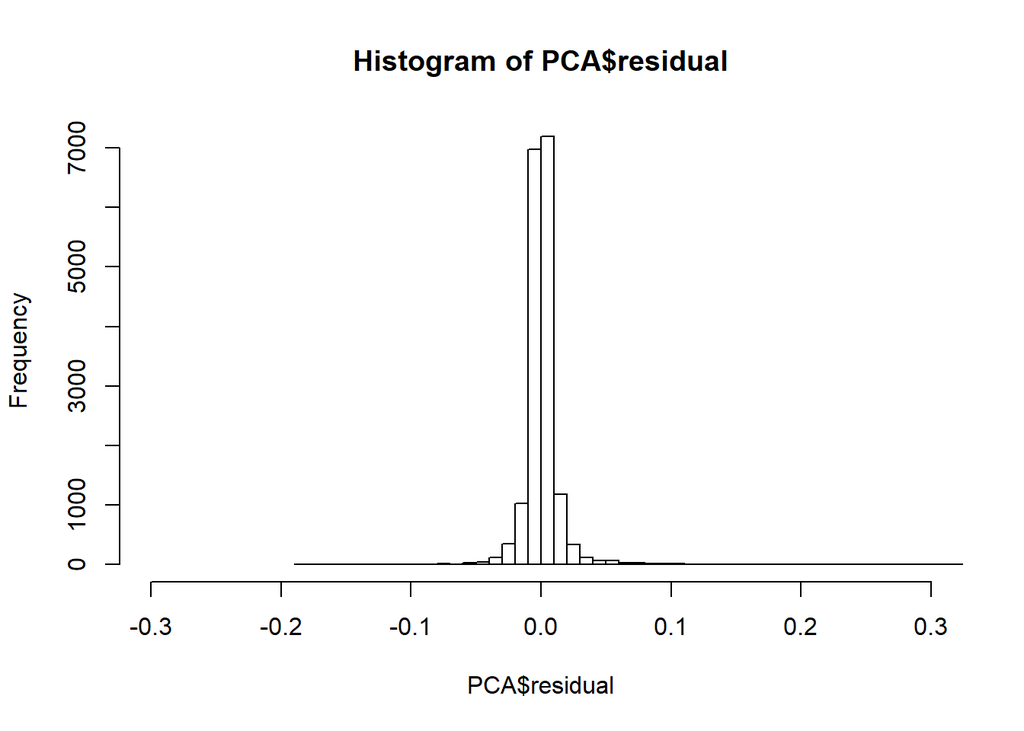

```r
hist(PCA$residual,breaks=100,xlim=c(-0.3,0.3))
```

```r
# As we see, the PCA converted quit good with RMSA of 0.01 and absolute majority of residuals close to z
# Now all we have to do is compute PCs on training and test sets

pc_train <- data.frame(user_name=train_data1$user_name,classe=train_data1$classe,
                        predict(PCA,data=train_data1[sapply(train_data1,is.numeric)])) %>%
  as_tibble()

pc_test <- data.frame(user_name=train_data1$user_name,classe=train_data1$classe,
                        predict(PCA,data=train_data1[sapply(train_data1,is.numeric)])) %>%
  as_tibble()
```

# Model training

As we have quite large sets of predictors and large number of variables, I believe it’s reasonable here to make stacked model ensemble of 4:  
1. Boosted tree on raw predictors with xgboost  
2. Boosted tree on principal components with xgboost  
3. Random forest on raw predictors with ranger  
4. Random forest on principal components with ranger

Each of this models will be trained with random subsampling cross-validation and added to the ensemble if it displays tolerable out-of-sample errors

## 1. Boosted tree on raw predictors with xgboost

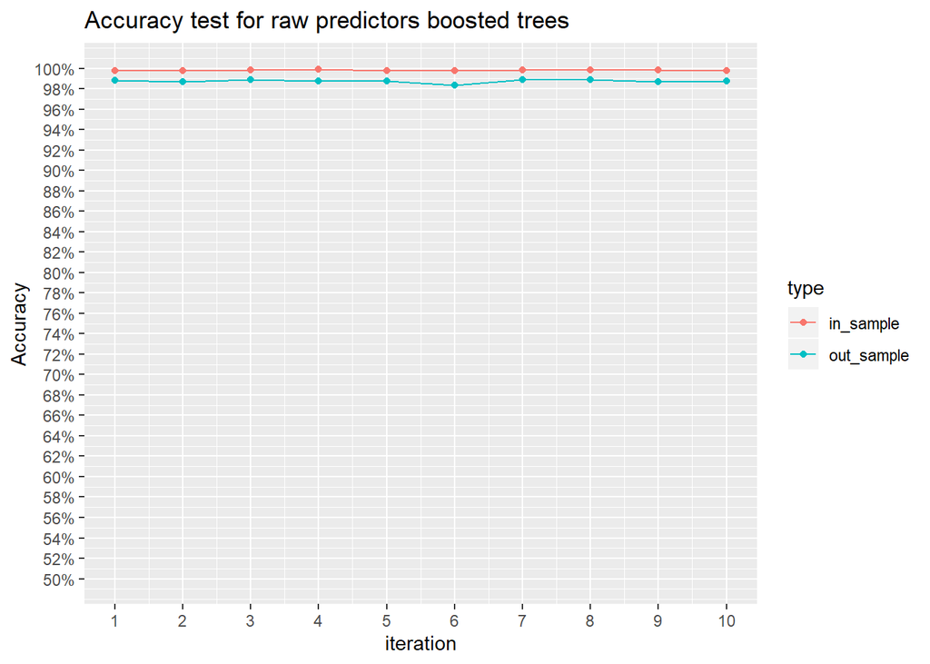

```r
set.seed(42)

xgb_raw <- NULL

for(i in 1:10){

  sampler <- sample(1:nrow(train_data1),0.66*nrow(train_data1))

  cv1 <- train_data1[sampler,-c(1,2)] %>% as.matrix()
  cv1_y <- train_data1[sampler,2] %>% mutate(classe=as.factor(classe),classe_n=as.integer(classe)-1)
  cv2 <- train_data1[-sampler,-c(1,2)] %>% as.matrix()
  cv2_y <- train_data1[-sampler,2] %>% mutate(classe=as.factor(classe),classe_n=as.integer(classe)-1)

  xgb_fit_raw <- xgb.train(data=xgb.DMatrix(data=cv1,label=cv1_y$classe_n,silent=TRUE),
                           params=list(booster="gbtree",
                                       eta=0.05,
                                       max_depth=10,
                                       gamma=3,
                                       objective="multi:softmax",
                                       num_class=length(unique(cv1_y$classe_n))),
                           nrounds=500,
                           verbose=0)

  xgb_pred_raw_train <- data.frame(orig=cv1_y$classe_n,pred=predict(xgb_fit_raw,xgb.DMatrix(data=cv1,silent=TRUE)))
  xgb_pred_raw_test <- data.frame(orig=cv2_y$classe_n,pred=predict(xgb_fit_raw,xgb.DMatrix(data=cv2,silent=TRUE)))

  error_check <- data.frame(iteration=i,
                            in_sample=sum(xgb_pred_raw_train[,1]==xgb_pred_raw_train[,2])/nrow(xgb_pred_raw_train),
                            out_sample=sum(xgb_pred_raw_test[,1]==xgb_pred_raw_test[,2])/nrow(xgb_pred_raw_test))

  xgb_raw <- rbind(xgb_raw,error_check)

}

ggplot(xgb_raw %>% gather(type,score,-1),aes(x=iteration,y=score))+
  geom_path(aes(color=type))+
  geom_point(aes(color=type))+
  scale_x_continuous(breaks = 1:10)+
  scale_y_continuous(name="Accuracy",limits=c(0.5,1),breaks=seq(0.5,1,0.02),labels=paste0(seq(0.5,1,0.02)*100,"%"))+
  ggtitle("Accuracy test for raw predictors boosted trees")
```

## 2. Boosted tree on principal components with xgboost

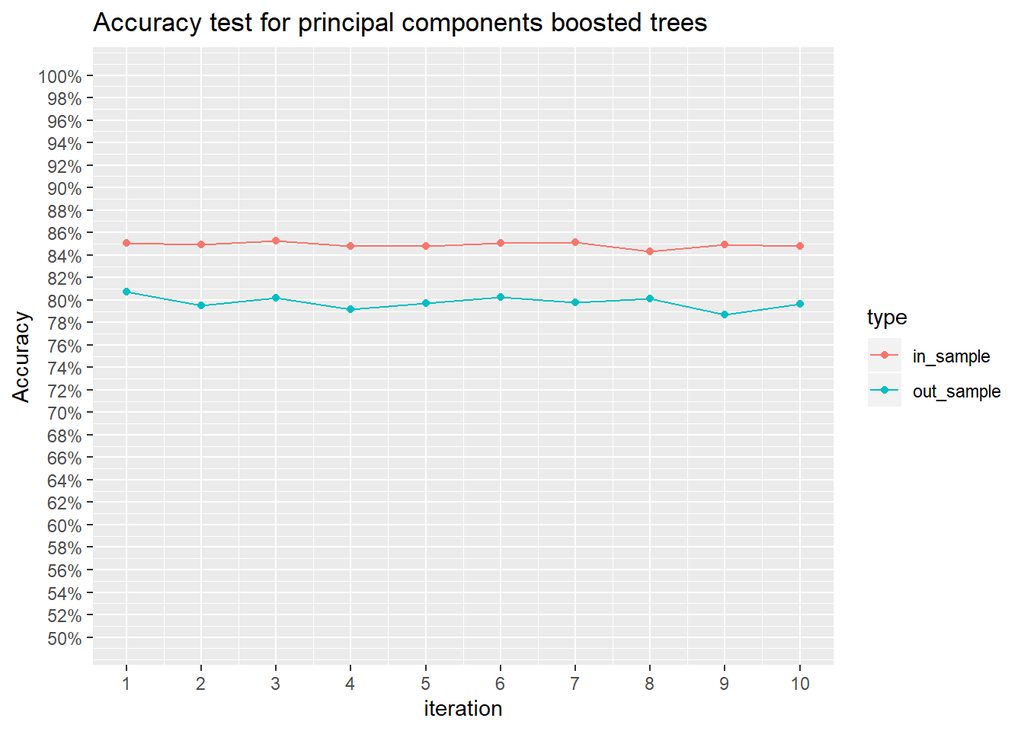

```r
set.seed(42)

xgb_pc <- NULL

for(i in 1:10){

  sampler <- sample(1:nrow(train_data1),0.66*nrow(train_data1))

  cv1 <- pc_train[sampler,-c(1,2)] %>% as.matrix()
  cv1_y <- pc_train[sampler,2] %>% mutate(classe=as.factor(classe),classe_n=as.integer(classe)-1)
  cv2 <- pc_test[-sampler,-c(1,2)] %>% as.matrix()
  cv2_y <- pc_test[-sampler,2] %>% mutate(classe=as.factor(classe),classe_n=as.integer(classe)-1)

  xgb_fit_pc <- xgb.train(data=xgb.DMatrix(data=cv1,label=cv1_y$classe_n,silent=TRUE),
                           params=list(booster="gbtree",
                                       eta=0.05,
                                       max_depth=3,
                                       gamma=3,
                                       objective="multi:softmax",
                                       num_class=length(unique(cv1_y$classe_n))),
                           nrounds=500,
                           verbose=0)

  xgb_pred_pc_train <- data.frame(orig=cv1_y$classe_n,pred=predict(xgb_fit_pc,xgb.DMatrix(data=cv1,silent=TRUE)))
  xgb_pred_pc_test <- data.frame(orig=cv2_y$classe_n,pred=predict(xgb_fit_pc,xgb.DMatrix(data=cv2,silent=TRUE)))

  error_check <- data.frame(iteration=i,
                            in_sample=sum(xgb_pred_pc_train[,1]==xgb_pred_pc_train[,2])/nrow(xgb_pred_pc_train),
                            out_sample=sum(xgb_pred_pc_test[,1]==xgb_pred_pc_test[,2])/nrow(xgb_pred_pc_test))

  xgb_pc <- rbind(xgb_pc,error_check)

}

ggplot(xgb_pc %>% gather(type,score,-1),aes(x=iteration,y=score))+
  geom_path(aes(color=type))+
  geom_point(aes(color=type))+
  scale_x_continuous(breaks = 1:10)+
  scale_y_continuous(name="Accuracy",limits=c(0.5,1),breaks=seq(0.5,1,0.02),labels=paste0(seq(0.5,1,0.02)*100,"%"))+
  ggtitle("Accuracy test for principal components boosted trees")
```

For boosted trees based on PC there is a more recognizable drop in accuracy from in sample to out of sample accuracy, 4-5%. The accuracy itself is less promising and generally lower than for raw boosted trees.

## 3. Random forest on raw predictors with ranger

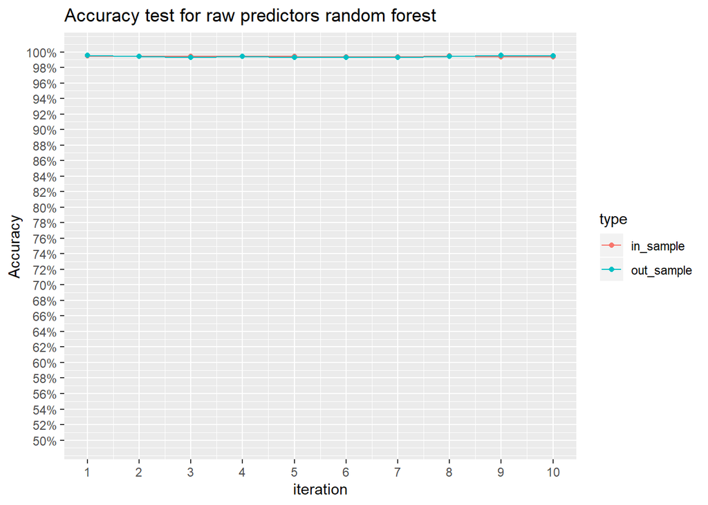

```r
set.seed(42)

rf_raw <- NULL

for(i in 1:10){

  sampler <- sample(1:nrow(train_data1),0.66*nrow(train_data1))

  cv1 <- train_data1[sampler,-1] %>% mutate(classe=as.factor(classe))
  cv2 <- train_data1[-sampler,-1] %>% mutate(classe=as.factor(classe))

  rf_fit_raw <- ranger(formula="classe~.",
                       data=cv1 %>% as.data.frame(),
                       num.trees=500,
                       mtry=round(sqrt(ncol(cv1)-1),0),
                       write.forest=TRUE,
                       splitrule="gini",
                       verbose=FALSE)

  # You need to be very accurate here - ranger cannot be shown observations it has already seen in trarining
  # It will results in major overfit of predictions
  # That's why I get predictions on training data from the ranger object directly
  rf_fit_raw_train <- data.frame(orig=cv1$classe,pred=rf_fit_raw$predictions)
  rf_fit_raw_test <- data.frame(orig=cv2$classe,pred=predict(rf_fit_raw,cv2)$predictions)

  error_check <- data.frame(iteration=i,
                            in_sample=sum(rf_fit_raw_train[,1]==rf_fit_raw_train[,2])/nrow(rf_fit_raw_train),
                            out_sample=sum(rf_fit_raw_test[,1]==rf_fit_raw_test[,2])/nrow(rf_fit_raw_test))

  rf_raw <- rbind(rf_raw,error_check)

}

ggplot(rf_raw %>% gather(type,score,-1),aes(x=iteration,y=score))+
  geom_path(aes(color=type))+
  geom_point(aes(color=type))+
  scale_x_continuous(breaks = 1:10)+
  scale_y_continuous(name="Accuracy",limits=c(0.5,1),breaks=seq(0.5,1,0.02),labels=paste0(seq(0.5,1,0.02)*100,"%"))+
  ggtitle("Accuracy test for raw predictors random forest")
```

## 4. Random forest on principal components with ranger

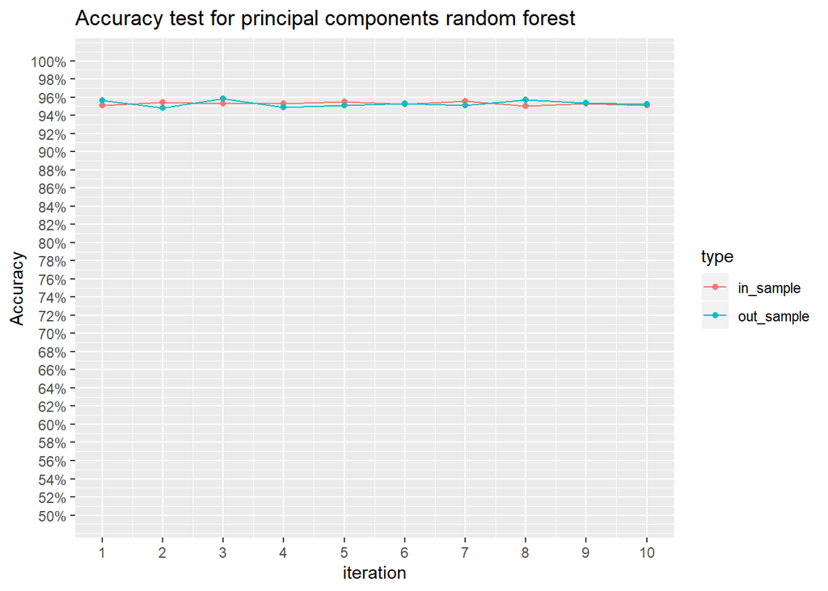

```r
set.seed(42)

rf_pc <- NULL

for(i in 1:10){

  sampler <- sample(1:nrow(train_data1),0.66*nrow(train_data1))

  cv1 <- pc_train[sampler,-1] %>% mutate(classe=as.factor(classe))
  cv2 <- pc_train[-sampler,-1] %>% mutate(classe=as.factor(classe))

  rf_fit_pc <- ranger(formula="classe~.",
                       data=cv1 %>% as.data.frame(),
                       num.trees=500,
                       mtry=round(sqrt(ncol(cv1)-1),0),
                       write.forest=TRUE,
                       splitrule="gini",
                       verbose=FALSE)

  rf_fit_pc_train <- data.frame(orig=cv1$classe,pred=rf_fit_pc$predictions)
  rf_fit_pc_test <- data.frame(orig=cv2$classe,pred=predict(rf_fit_pc,cv2)$predictions)

  error_check <- data.frame(iteration=i,
                            in_sample=sum(rf_fit_pc_train[,1]==rf_fit_pc_train[,2])/nrow(rf_fit_pc_train),
                            out_sample=sum(rf_fit_pc_test[,1]==rf_fit_pc_test[,2])/nrow(rf_fit_pc_test))

  rf_pc <- rbind(rf_pc,error_check)

}

ggplot(rf_pc %>% gather(type,score,-1),aes(x=iteration,y=score))+
  geom_path(aes(color=type))+
  geom_point(aes(color=type))+
  scale_x_continuous(breaks = 1:10)+
  scale_y_continuous(name="Accuracy",limits=c(0.5,1),breaks=seq(0.5,1,0.02),labels=paste0(seq(0.5,1,0.02)*100,"%"))+
  ggtitle("Accuracy test for principal components random forest")
```

Random forest on principal components has less accuracy compared to raw predictors one, some 0.95. The diversion of in-sample and out of sample accuracies is a bit bigger too.

Thus, we have 4 models, with each of them displaying quite good accuracy and reasonable out-of-sample errors. No it’s finally the time to validate them with test data on them own and in a an ensemble

# Test-data validation

```r
xgb_fit_raw
```

```
## ##### xgb.Booster
## raw: 12.4 Mb
## call:
##   xgb.train(params = list(booster = "gbtree", eta = 0.05, max_depth = 10,
##     gamma = 3, objective = "multi:softmax", num_class = length(unique(cv1_y$classe_n))),
##     data = xgb.DMatrix(data = cv1, label = cv1_y$classe_n, silent = TRUE),
##     nrounds = 500, verbose = 0)
## params (as set within xgb.train):
##   booster = "gbtree", eta = "0.05", max_depth = "10", gamma = "3", objective = "multi:softmax", num_class = "5", silent = "1"
## xgb.attributes:
##   niter
## # of features: 133
## niter: 500
## nfeatures : 133
```

```r
xgb_fit_pc
```

```
## ##### xgb.Booster
## raw: 1.6 Mb
## call:
##   xgb.train(params = list(booster = "gbtree", eta = 0.05, max_depth = 3,
##     gamma = 3, objective = "multi:softmax", num_class = length(unique(cv1_y$classe_n))),
##     data = xgb.DMatrix(data = cv1, label = cv1_y$classe_n, silent = TRUE),
##     nrounds = 500, verbose = 0)
## params (as set within xgb.train):
##   booster = "gbtree", eta = "0.05", max_depth = "3", gamma = "3", objective = "multi:softmax", num_class = "5", silent = "1"
## xgb.attributes:
##   niter
## # of features: 17
## niter: 500
## nfeatures : 17
```

```r
rf_fit_raw
```

```
## Ranger result
##
## Call:
##  ranger(formula = "classe~.", data = cv1 %>% as.data.frame(),      num.trees = 500, mtry = round(sqrt(ncol(cv1) - 1), 0), write.forest = TRUE,      splitrule = "gini", verbose = FALSE)
##
## Type:                             Classification
## Number of trees:                  500
## Sample size:                      12950
## Number of independent variables:  133
## Mtry:                             12
## Target node size:                 1
## Variable importance mode:         none
## Splitrule:                        gini
## OOB prediction error:             0.63 %
```

```r
rf_fit_pc
```

```
## Ranger result
##
## Call:
##  ranger(formula = "classe~.", data = cv1 %>% as.data.frame(),      num.trees = 500, mtry = round(sqrt(ncol(cv1) - 1), 0), write.forest = TRUE,      splitrule = "gini", verbose = FALSE)
##
## Type:                             Classification
## Number of trees:                  500
## Sample size:                      12950
## Number of independent variables:  17
## Mtry:                             4
## Target node size:                 1
## Variable importance mode:         none
## Splitrule:                        gini
## OOB prediction error:             4.93 %
```

```r
test_predictions1 <- data.frame(user_name = test_data1$user_name,
  classe=test_data1$classe,
  xgb_raw_test=predict(xgb_fit_raw,xgb.DMatrix(data=test_data1[,-c(1,2)] %>% as.matrix(),silent=TRUE)),
  xgb_pc_test=predict(xgb_fit_pc,xgb.DMatrix(data=pc_test[,-c(1,2)] %>% as.matrix(),silent=TRUE)),
  rf_raw_test=predict(rf_fit_raw,test_data1[,-c(1,2)])$predictions %>% as.character(),
  rf_pc_test=predict(rf_fit_pc,pc_test[,-c(1,2)])$prediction %>% as.character(),
  row.names=NULL,
  stringsAsFactors=FALSE) %>%
  mutate(xgb_raw_test=recode(xgb_raw_test,`0`="A",`1`="B",`2`="C",`3`="D",`4`="E")) %>%
  mutate(xgb_pc_test=recode(xgb_pc_test,`0`="A",`1`="B",`2`="C",`3`="D",`4`="E"))

# Here we define cummulative prediction by majority. If there is a tie between models, the prediction will be defined as missed
test_predictions2 <- test_predictions1 %>%
  gather(model,cummulative,-c(user_name,classe)) %>%
  group_by(user_name,cummulative) %>%
  summarise(n=n()) %>%
  ungroup() %>%
  group_by(user_name) %>%
  filter(n==max(n)) %>%
  ungroup() %>%
  mutate(cummulative=ifelse(n==2,"missed",cummulative)) %>%
  select(-n) %>%
  distinct()

# As principal components boosted trees has shown poor performance, a separate cummultaive score is constructed without it
test_predictions3 <- test_predictions1 %>%
  select(-xgb_pc_test) %>%
  gather(model,cummulative_noxgbpc,-c(user_name,classe)) %>%
  group_by(user_name,cummulative_noxgbpc) %>%
  summarise(n=n()) %>%
  ungroup() %>%
  group_by(user_name) %>%
  filter(n==max(n)) %>%
  ungroup() %>%
  mutate(cummulative_noxgbpc=ifelse(n==1,"missed",cummulative_noxgbpc)) %>%
  select(-n) %>%
  distinct()

# Also, a separate cummulative score is constructed for 2 best models which are raw predictors
test_predictions4 <- test_predictions1 %>%
  select(-xgb_pc_test,-rf_pc_test) %>%
  gather(model,cummulative_nopc,-c(user_name,classe)) %>%
  group_by(user_name,cummulative_nopc) %>%
  summarise(n=n()) %>%
  ungroup() %>%
  group_by(user_name) %>%
  filter(n==max(n)) %>%
  ungroup() %>%
  mutate(cummulative_nopc=ifelse(n==1,"missed",cummulative_nopc)) %>%
  select(-n) %>%
  distinct()

test_fin <- test_predictions1 %>%
  inner_join(test_predictions2,by="user_name") %>%
  inner_join(test_predictions3,by="user_name") %>%
  inner_join(test_predictions4,by="user_name") %>%
  gather(predictor,prediction,-c(user_name,classe)) %>%
  group_by(predictor) %>%
  summarise(accuracy=sum(prediction==classe)/n()) %>%
  ungroup() %>%
  arrange(desc(accuracy))

kable(test_fin)
```

| predictor | accuracy |
| --- | --- |
| cummulative_noxgbpc | 0.9983692 |
| rf_raw_test | 0.9982163 |
| xgb_raw_test | 0.9942921 |
| cummulative_nopc | 0.9930180 |
| cummulative | 0.9843033 |
| rf_pc_test | 0.9837427 |
| xgb_pc_test | 0.8305473 |